# test MaCSTS 3

2026-06-08

## General Notes

This notebook follows `testMaCSTS2.Rmd` outputs and then:

1. runs `msprime_from_macs_scenarios.py` to generate msprime `.trees` and manifest;
2. runs `msprime_macs_scenarios_compare.py` to build a combined long table;
3. compares distributions across methods (`macs`, `macsTS`, `msprime`).

These tests are important because `MaCSTS` and the msprime bridge both rely on multiple unit conversions (tests on more scenarios are welcome!):

- sequence length;
- time unit conversion (coalescent-scaled time vs generations);
- mutation and recombination rate conversions;
- migration parameter conversions (global vs pairwise);
- sample-count mapping when ploidy changes.

The goal here is not exact replicate-by-replicate identity with msprime, but to check that scenario-level distributions (mutations, trees, edges, nodes, and root times) are consistent after these conversions.

Current order in MaCSTS when `useMacsMut = FALSE`:

1. During `buildTs()`, local trees are generated along the chromosome and each interval is recorded to TS edge/node tables (`recordTreeInterval`).
2. No MaCS mutation placement happens in this step (`addMutationsTs` is skipped).
3. At the end of `buildTs()`, ancestry is simplified (`TsRecorder::simplify`).
4. On `release()`, times are rescaled (if `Nref` was provided), then tables are sorted and indexed.
5. Post-TS mutation (if requested) is applied later by `simMut()` / `tsMutateTableCollection()` on the already simplified/rescaled ancestry.
6. Inbred leaf expansion is optional and can be deferred to `finalizeInbredTs()` (this is what `simAnc(..., expandInbredSamples = FALSE)` does in the staged workflow).

```r
find_dev_dir <- function() {
  if (file.exists("msprime_from_macs_scenarios.py")) return(normalizePath(".", winslash = "/"))
  if (file.exists("dev/msprime_from_macs_scenarios.py")) return(normalizePath("dev", winslash = "/"))
  stop("Cannot find dev directory containing msprime_from_macs_scenarios.py")
}

dev_dir <- find_dev_dir()
py_sim_script <- file.path(dev_dir, "msprime_from_macs_scenarios.py")
py_cmp_script <- file.path(dev_dir, "msprime_macs_scenarios_compare.py")

macsts_manifest <- file.path(dev_dir, "testData/out_phase1_useMacsMut_FALSE/phase1_macsTS_useMacsMut_FALSE_manifest.csv")
msprime_manifest <- file.path(dev_dir, "testData/out_msprime_from_macs/msprime_manifest.csv")
comparison_long_csv <- file.path(dev_dir, "testData/method_comparison_long.csv")

stopifnot(file.exists(py_sim_script))
stopifnot(file.exists(py_cmp_script))
stopifnot(file.exists(macsts_manifest))
```

## Run Python Scripts

```r
run_python_script <- function(dev_dir, script_name, args = character()) {
  # Use your own path here!
  py <- '/usr/bin/python3'

  old <- getwd()
  on.exit(setwd(old), add = TRUE)
  setwd(dev_dir)
  status <- system2(py, args = c(script_name, args))
  if (!identical(status, 0L)) stop("Failed to run ", script_name, " (exit status ", status, ")")
}

# 1) Generate msprime replicates + manifest.
# Conversion details implemented in msprime_from_macs_scenarios.py:
# - seq length: token 2nd in MaCS args is passed to msprime sequence_length.
# - time: MaCS scaled times are converted to generations by t_gen = t * 4 * Nref.
# - recombination: rec_rate_bp = r / (4 * Nref).
# - mutation: mut_rate_bp = theta / (4 * Nref), then applied via sim_mutations().
# - migration:
#     global M  -> pairwise m_ij = M / ((k-1) * 4 * Nref) for k populations;
#     pair Mij  -> m_ij = Mij / (4 * Nref).
# - samples/ploidy:
#     script currently runs msprime with ploidy=2, so MaCS haploid sample counts
#     per population are halved (must be even) before passing to `samples=`.
run_python_script(
  dev_dir = dev_dir,
  script_name = basename(py_sim_script),
  args = c(
    "--nrep", "50",
    "--nchr", "1",
    "--nref", "10000",
    "--base-seed", "700000",
    "--model", "smc_prime",
    "--out-dir", "testData/out_msprime_from_macs"
  )
)

# 2) Build cross-method comparison summary + long table.
# msprime_macs_scenarios_compare.py reads:
# - MaCSTS manifest (from testMaCSTS2),
# - msprime manifest (from step 1),
# and writes a long-format table used below for distribution plots.
run_python_script(
  dev_dir = dev_dir,
  script_name = basename(py_cmp_script)
)
```

## Distribution Comparison Plots

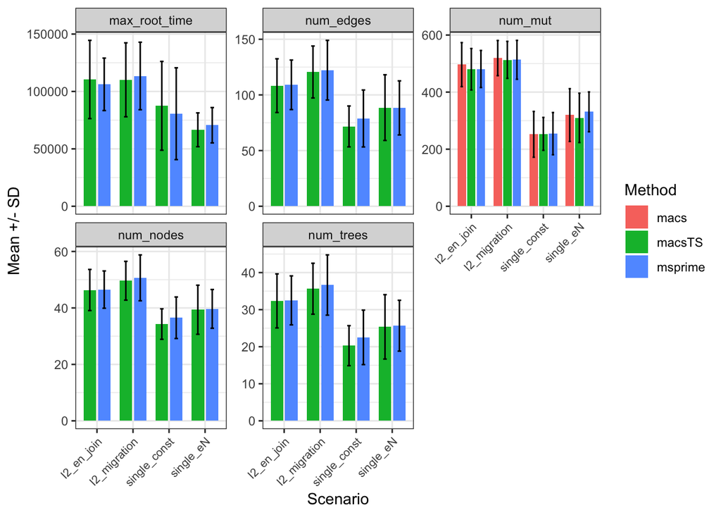

```r
stopifnot(file.exists(comparison_long_csv))
cmp <- read.csv(comparison_long_csv, stringsAsFactors = FALSE)


num_cols <- c("num_mut", "num_trees", "num_edges", "num_nodes", "max_root_time")
for (nm in num_cols) {
  cmp[[nm]] <- suppressWarnings(as.numeric(cmp[[nm]]))
}

library(dplyr)
library(tidyr)
library(ggplot2)

metrics <- c("num_mut", "num_trees", "num_edges", "num_nodes", "max_root_time")

long_df <- cmp %>%
  pivot_longer(cols = all_of(metrics), names_to = "metric", values_to = "value") %>%
  filter(!is.na(value))

# Mean + SD bars by scenario/method for each metric
summary_df <- long_df %>%
  group_by(Scenarios, Methods, metric) %>%
  summarise(mean = mean(value), sd = sd(value), .groups = "drop")

ggplot(summary_df, aes(x = Scenarios, y = mean, fill = Methods)) +
  geom_col(position = position_dodge(width = 0.8), width = 0.7) +
  geom_errorbar(
    aes(ymin = mean - sd, ymax = mean + sd),
    position = position_dodge(width = 0.8),
    width = 0.2
  ) +
  facet_wrap(~ metric, scales = "free_y") +
  labs(x = "Scenario", y = "Mean +/- SD", fill = "Method") +
  theme_bw()+
  theme(
    axis.text.x = element_text(angle = 45, hjust = 1, size = 8)
  )
```